# Modified update probabilities for the model

This notebook uses the compiled JAR file in the repository (*dist* directory in https://github.com/jgtz/BreastCancerModelv2/), and executes it through Python.

```python
from subprocess import Popen, PIPE, STDOUT
import sys
import os
import pandas as pd
import matplotlib.pyplot as plt
from IPython.display import Image
%pylab inline
%matplotlib inline
```

```python
pylab.rcParams['figure.figsize'] = (2.7, 1.5);mpl.rcParams['lines.linewidth'] = 2;mpl.rcParams['lines.markersize'] = 5;
pylab.rcParams['lines.markeredgewidth'] =  0.5;matplotlib.rcParams.update({'font.size': 12})
```

These functions allow us to call the JAR file, generate the files needed to run the model (e.g. the Boolean tables), run simulations, and read the files generated by the simulations.

```python
def run_BCmodel(parameters, jar_path,quiet=False):
    proc = Popen(['java', '-jar', jar_path]+parameters, stdout=PIPE, stderr=STDOUT)
    with proc.stdout:
        for line in iter(proc.stdout.readline, b''):
            if quiet:
                continue
            sys.stdout.write(line)

def generate_BCmodel(filename, jar_path,quiet=False):
    proc = Popen(['java', '-jar', jar_path]+["Generate",filename], stdout=PIPE, stderr=STDOUT)
    with proc.stdout:
        for line in iter(proc.stdout.readline, b''):
            if quiet:
                continue
            sys.stdout.write(line)

def get_parameters(filename,initial_conditions,normalized_time_steps,write_timecourse,perturbation_nodes=[],perturbation_states=[]):
    #The JAR file expect the following arguments. Curently we only support perturbations of up to size 4 through this method.

    #args[0] is the mode in which to run the program. Options: "Run", "Generate", "GenerateAndRun","Run_ThirdTimeScale", "BreastCancerModel_ZanudoEtAl2017"
    #args[1] is the name of the TXT file where the model is.
    #args[2] is the number of initial conditions to run.
    #args[3] is the number of normalized time steps (number of timesteps equal to the average time needed to update a slow node) to run.
    #args[4] Whether to write to file the timecourse. Takes the values (without quotes) "true" or "false".
    #args[5] is the node name of the first perturbation, args[6] is the state of the first perturbation
    #args[7] is the node name of the second perturbation, args[8] is the state of the second perturbation
    #args[9] is the node name of the third perturbation, args[10] is the state of the third perturbation
    #args[11] is the node name of the fourth perturbation, args[12] is the state of the fourth perturbation
    parameters=["Run",filename,str(initial_conditions),str(normalized_time_steps),write_timecourse]


    if(len(perturbation_nodes)!=len(perturbation_states)):
        raise Exception("Error: perturbation_nodes and perturbation_nodes must have the same length")

    if(len(perturbation_nodes)>4):
        raise Exception("Error: Only up to 4 perturbations are allowed")

    for n,s in zip(perturbation_nodes,perturbation_states):
        parameters.append(n)
        parameters.append(s)

    return(parameters)

def get_parameters_2(filename,initial_conditions,normalized_time_steps,write_timecourse,perturbation_nodes=[],perturbation_states=[]):
    #The JAR file expect the following arguments. Curently we only support perturbations of up to size 4 through this method.

    #args[0] is the mode in which to run the program. Options: "Run", "Generate", "GenerateAndRun", "Run_ThirdTimeScale", "BreastCancerModel_ZanudoEtAl2017"
    #args[1] is the name of the TXT file where the model is.
    #args[2] is the number of initial conditions to run.
    #args[3] is the number of normalized time steps (number of timesteps equal to the average time needed to update a slow node) to run.
    #args[4] Whether to write to file the timecourse. Takes the values (without quotes) "true" or "false".
    #args[5] is the node name of the first perturbation, args[6] is the state of the first perturbation
    #args[7] is the node name of the second perturbation, args[8] is the state of the second perturbation
    #args[9] is the node name of the third perturbation, args[10] is the state of the third perturbation
    #args[11] is the node name of the fourth perturbation, args[12] is the state of the fourth perturbation
    parameters=["Run_ThirdTimeScale",filename,str(initial_conditions),str(normalized_time_steps),write_timecourse]


    if(len(perturbation_nodes)!=len(perturbation_states)):
        raise Exception("Error: perturbation_nodes and perturbation_nodes must have the same length")

    if(len(perturbation_nodes)>4):
        raise Exception("Error: Only up to 4 perturbations are allowed")

    for n,s in zip(perturbation_nodes,perturbation_states):
        parameters.append(n)
        parameters.append(s)

    return(parameters)

def read_in_timecourse(basename,perturbation_nodes,perturbation_states,timecourses_directory="timecourses/"):
    perturbation_string="_".join([x[0]+"="+x[1] for x in zip(perturbation_nodes,perturbation_states)])
    if(perturbation_string!=""):
        timecourse_file_name='timecourse'+basename+"_"+perturbation_string+'.txt'
    else:
        timecourse_file_name='timecourse'+basename+perturbation_string+'.txt'
    df=pd.read_csv(timecourses_directory+timecourse_file_name,sep='\t',index_col=0)
    df=df.dropna(axis=1)
    df=df.append(pd.DataFrame(data=[df.columns],index=["time"],columns=df.columns,dtype="float64"))
    df.columns=[i for i,j in enumerate(df.columns)]
    df_timecourse=df
    return(df_timecourse)

def read_in_timecourse_2(basename,perturbation_nodes,perturbation_states,timecourses_directory="timecourses/"):
    perturbation_string="_".join([x[0]+"="+x[1] for x in zip(perturbation_nodes,perturbation_states)])
    if(perturbation_string!=""):
        timecourse_file_name='timecourse'+basename+"_"+perturbation_string+'_ThreeTimeScales.txt'
    else:
        timecourse_file_name='timecourse'+basename+perturbation_string+'_ThreeTimeScales.txt'
    df=pd.read_csv(timecourses_directory+timecourse_file_name,sep='\t',index_col=0)
    df=df.dropna(axis=1)
    df=df.append(pd.DataFrame(data=[df.columns],index=["time"],columns=df.columns,dtype="float64"))
    df.columns=[i for i,j in enumerate(df.columns)]
    df_timecourse=df
    return(df_timecourse)
```

Here we specify the parameters needed for the simulation:

- The path of the JAR file.
- The location of the model files.
- The number of initial conditions for the simulations.
- The number of time steps for each simulation.
- Whether to output a file with the average state of each node at every time step.

```python
jar_path="../dist/BreastCancerModel.jar"
#filename="models/BreastCancerModel_ZanudoEtAl2017.booleannet"
filename_model_M="../Models/BreastCancerModel_ZanudoEtAl2020_MCF7.booleannet"
initial_conditions=10000
normalized_time_steps=25
write_timecourse="true"
```

We first need to generate the Boolean tables of the model, which will then be used to run the timecourse simulations.

```python
generate_BCmodel(filename_model_M,jar_path)
```

```
Filename: ../Models/BreastCancerModel_ZanudoEtAl2020_MCF7.booleannet
Creating Boolean table directory: BreastCancerModel_ZanudoEtAl2020_MCF7
Boolean table directory created.
Functions and names files created.
Creating network model...
Model created.
Exiting program
```

# Model simulations

We now run each of the cell-line-specific models (MCF7, T47D) in the presence of different perturbations starting from the cancerous state of each of the models. To run these simulations, we need 3 files that specify (1) the initial conditions, (2) the fast and slow nodes of the simulation, and (3) the weights for determining $Apoptosis_{norm}$ and $Proliferation_{norm}$.

**Initial conditions**

The initial conditions are specified in the *ModelName_InitialConditions.txt* files, where *ModelName* is either *BreastCancerModel_ZanudoEtAl2020_MCF7* or *BreastCancerModel_ZanudoEtAl2020_T47D*.

**Fast and slow nodes**

The slow and fast nodes are specified in the *ModelName_SlowFastNodes.txt* files. The file contains the name of the slow nodes and the fast nodes are taken to be the ones not specified in this file.

**Weights for $Apoptosis_{norm}$ and $Proliferation_{norm}$**

The weights are specified in the *ModelName_ApoptosisProliferationWeights.txt* files. Each row is tab-separated. The first row has the weights of $Apoptosis_{norm}$ in the following order: weight for Apoptosis=1, weight for Apoptosis=2, and weight for Apoptosis=3. The second row has the weights of $Proliferation_{norm}$ in the following order: weight for Prolfieration=1, weight for Proliferation=2, weight for Proliferation=3, and weight for Proliferation=4.

Note: For these models we set the weight for Proliferation=4 to be 0, since the maximum state of Proliferation is 3. The Zanudo et al. 2017 has a Proliferation=4 state, and in that case the associated weight would not be 0.

# Testing modified update probabilities

For all the simulations, we used a single update probability ($p_{slow}$) for all slow nodes and a single update probability ($p_{fast}$) for all fast nodes. Following our 2017 model, the fast probability was chosen to be 5 times faster than the slow probability ($p_{fast}=5 p_{slow}$).

The use of only two update probabilities ($p_{fast}$, $p_{slow}$) does not fully capture the heterogeneous timescales of these processes, and is meant to be a crude approximation. However, it is important to note that, because of the stochasticity of the asynchronous updatings scheme, each simulation is sampling multiple update orders (even if the update probability is fixed), and these update orders are what give rise to the probability of the system to end up in different attractors.

Here we want to test a few processes that one might suspect are slower than what is currently being captured by $p_{slow}$. In particular we look at the nodes $Apoptosis$, $Proliferation$, $ER\_transcription\_feedback\_1$, and $ER\_transcription\_feedback\_2$. In the following, we will only look at the results for MCF7 model.

```python
parameters=get_parameters(filename_model_M,initial_conditions,normalized_time_steps,write_timecourse)
run_BCmodel(parameters, jar_path,quiet=False)

parameters=get_parameters_2(filename_model_M,initial_conditions,normalized_time_steps,write_timecourse)
run_BCmodel(parameters, jar_path,quiet=False)

PerturbationNodes_list=[]
PerturbationStates_list=[]

perturbation_nodes=["Alpelisib"]
perturbation_states=["1"]
PerturbationNodes_list.append(perturbation_nodes)
PerturbationStates_list.append(perturbation_states)

perturbation_nodes=["Alpelisib","FOXO3"]
perturbation_states=["1","0"]
PerturbationNodes_list.append(perturbation_nodes)
PerturbationStates_list.append(perturbation_states)

perturbation_nodes=["Alpelisib","S63845"]
perturbation_states=["1","1"]
PerturbationNodes_list.append(perturbation_nodes)
PerturbationStates_list.append(perturbation_states)

perturbation_nodes=["Alpelisib","p21_p27_T"]
perturbation_states=["1","0"]
PerturbationNodes_list.append(perturbation_nodes)
PerturbationStates_list.append(perturbation_states)

perturbation_nodes=["Alpelisib","Rb_T"]
perturbation_states=["1","0"]
PerturbationNodes_list.append(perturbation_nodes)
PerturbationStates_list.append(perturbation_states)

for perturbation_nodes,perturbation_states in zip(PerturbationNodes_list,PerturbationStates_list):
    normalized_time_steps=25
    parameters=get_parameters(filename_model_M,initial_conditions,normalized_time_steps,write_timecourse,perturbation_nodes,perturbation_states)
    run_BCmodel(parameters, jar_path,quiet=False)
    normalized_time_steps=100
    parameters=get_parameters_2(filename_model_M,initial_conditions,normalized_time_steps,write_timecourse,perturbation_nodes,perturbation_states)
    run_BCmodel(parameters, jar_path,quiet=False)
```

```
Filename: ../Models/BreastCancerModel_ZanudoEtAl2020_MCF7.booleannet
Creating network model based on Boolean tables, functions, and names files...
Model created.
Perturbation	Apofrac1	Apofrac2	Apofrac3	Apofrac	Prolfrac1	Prolfrac2	Prolfrac3	Prolfrac4	Prolfrac
No Perturbation	0.0	0.0	0.0	0.0	1.0	1.0	1.0	0.0	1.0

Filename: ../Models/BreastCancerModel_ZanudoEtAl2020_MCF7.booleannet
Creating network model based on Boolean tables, functions, and names files...
Model created.
Perturbation	Apofrac1	Apofrac2	Apofrac3	Apofrac	Prolfrac1	Prolfrac2	Prolfrac3	Prolfrac4	Prolfrac
No Perturbation	0.0	0.0	0.0	0.0	1.0	1.0	1.0	0.0	1.0

Filename: ../Models/BreastCancerModel_ZanudoEtAl2020_MCF7.booleannet
Creating network model based on Boolean tables, functions, and names files...
Model created.
Perturbation	Apofrac1	Apofrac2	Apofrac3	Apofrac	Prolfrac1	Prolfrac2	Prolfrac3	Prolfrac4	Prolfrac
Alpelisib=1	1.0	0.0	0.0	0.25	1.0	8.0E-4	1.0E-4	0.0	0.250275

Filename: ../Models/BreastCancerModel_ZanudoEtAl2020_MCF7.booleannet
Creating network model based on Boolean tables, functions, and names files...
Model created.
Perturbation	Apofrac1	Apofrac2	Apofrac3	Apofrac	Prolfrac1	Prolfrac2	Prolfrac3	Prolfrac4	Prolfrac
Alpelisib=1	1.0	0.0	0.0	0.25	1.0	1.0E-4	0.0	0.0	0.250025

Filename: ../Models/BreastCancerModel_ZanudoEtAl2020_MCF7.booleannet
Creating network model based on Boolean tables, functions, and names files...
Model created.
Perturbation1	Perturbation2	Apofrac1	Apofrac2	Apofrac3	Apofrac	Prolfrac1	Prolfrac2	Prolfrac3	Prolfrac4	Prolfrac
Alpelisib=1	FOXO3=0	0.3363	0.0	0.0	0.084075	1.0	1.0	0.0	0.0	0.5

Filename: ../Models/BreastCancerModel_ZanudoEtAl2020_MCF7.booleannet
Creating network model based on Boolean tables, functions, and names files...
Model created.
Perturbation1	Perturbation2	Apofrac1	Apofrac2	Apofrac3	Apofrac	Prolfrac1	Prolfrac2	Prolfrac3	Prolfrac4	Prolfrac
Alpelisib=1	FOXO3=0	0.3309	0.0	0.0	0.082725	1.0	1.0	0.0	0.0	0.5

Filename: ../Models/BreastCancerModel_ZanudoEtAl2020_MCF7.booleannet
Creating network model based on Boolean tables, functions, and names files...
Model created.
Perturbation1	Perturbation2	Apofrac1	Apofrac2	Apofrac3	Apofrac	Prolfrac1	Prolfrac2	Prolfrac3	Prolfrac4	Prolfrac
```

[output cut: 16 more lines]

```
Model created.
Perturbation1	Perturbation2	Apofrac1	Apofrac2	Apofrac3	Apofrac	Prolfrac1	Prolfrac2	Prolfrac3	Prolfrac4	Prolfrac
Alpelisib=1	p21_p27_T=0	1.0	0.0	0.0	0.25	1.0	1.0	0.0	0.0	0.5

Filename: ../Models/BreastCancerModel_ZanudoEtAl2020_MCF7.booleannet
Creating network model based on Boolean tables, functions, and names files...
Model created.
Perturbation1	Perturbation2	Apofrac1	Apofrac2	Apofrac3	Apofrac	Prolfrac1	Prolfrac2	Prolfrac3	Prolfrac4	Prolfrac
Alpelisib=1	Rb_T=0	1.0	0.0	0.0	0.25	1.0	1.0	0.0	0.0	0.5

Filename: ../Models/BreastCancerModel_ZanudoEtAl2020_MCF7.booleannet
Creating network model based on Boolean tables, functions, and names files...
Model created.
Perturbation1	Perturbation2	Apofrac1	Apofrac2	Apofrac3	Apofrac	Prolfrac1	Prolfrac2	Prolfrac3	Prolfrac4	Prolfrac
Alpelisib=1	Rb_T=0	1.0	0.0	0.0	0.25	1.0	1.0	0.0	0.0	0.5
```

```python
import shutil

source = './'
dest1 = './timecourses_ModifiedUpdateProbabilities/'

files = os.listdir(source)

for f in files:
    bnfile=os.path.basename(f)
    if bnfile.startswith("timecourseBreastCancerModel"):
        #print(bnfile)
        shutil.copy(source+f, dest1)
        os.remove(source+f)
    if bnfile.startswith("timecourseSEMBreastCancerModel"):
        #print(bnfile)
        shutil.copy(source+f, dest1)
        os.remove(source+f)

basename=os.path.basename(filename_model_M).split(".")[0]

perturbation_nodes=[]
perturbation_states=[]
df_timecourse=read_in_timecourse(basename,perturbation_nodes,perturbation_states,dest1)
df_timecourse_alpelisib_0_M=df_timecourse.T
df_timecourse=read_in_timecourse_2(basename,perturbation_nodes,perturbation_states,dest1)
df_timecourse_alpelisib_0_M_3timescales=df_timecourse.T

perturbation_nodes=["Alpelisib"]
perturbation_states=["1"]
df_timecourse=read_in_timecourse(basename,perturbation_nodes,perturbation_states,dest1)
df_timecourse_alpelisib_1_M=df_timecourse.T
df_timecourse=read_in_timecourse_2(basename,perturbation_nodes,perturbation_states,dest1)
df_timecourse_alpelisib_1_M_3timescales=df_timecourse.T

perturbation_nodes=["Alpelisib","FOXO3"]
perturbation_states=["1","0"]
df_timecourse=read_in_timecourse(basename,perturbation_nodes,perturbation_states,dest1)
df_timecourse_alpelisib_1_foxo3_0_M=df_timecourse.T
df_timecourse=read_in_timecourse_2(basename,perturbation_nodes,perturbation_states,dest1)
df_timecourse_alpelisib_1_foxo3_0_M_3timescales=df_timecourse.T


perturbation_nodes=["Alpelisib","Rb_T"]
perturbation_states=["1","0"]
df_timecourse=read_in_timecourse(basename,perturbation_nodes,perturbation_states,dest1)
df_timecourse_alpelisib_1_RbT_0_M=df_timecourse.T
df_timecourse=read_in_timecourse_2(basename,perturbation_nodes,perturbation_states,dest1)
df_timecourse_alpelisib_1_RbT_0_M_3timescales=df_timecourse.T

perturbation_nodes=["Alpelisib","S63845"]
perturbation_states=["1","1"]
df_timecourse=read_in_timecourse(basename,perturbation_nodes,perturbation_states,dest1)
df_timecourse_alpelisib_1_S63845_1_M=df_timecourse.T
df_timecourse=read_in_timecourse_2(basename,perturbation_nodes,perturbation_states,dest1)
df_timecourse_alpelisib_1_S63845_1_M_3timescales=df_timecourse.T


perturbation_nodes=["Alpelisib","p21_p27_T"]
perturbation_states=["1","0"]
df_timecourse=read_in_timecourse(basename,perturbation_nodes,perturbation_states,dest1)
df_timecourse_alpelisib_1_P21P27T_0_M=df_timecourse.T
df_timecourse=read_in_timecourse_2(basename,perturbation_nodes,perturbation_states,dest1)
df_timecourse_alpelisib_1_P21P27T_0_M_3timescales=df_timecourse.T
```

# Timecourse of selected perturbations

Here we show the timecourse of selected perturbations for the MCF7-specific model.

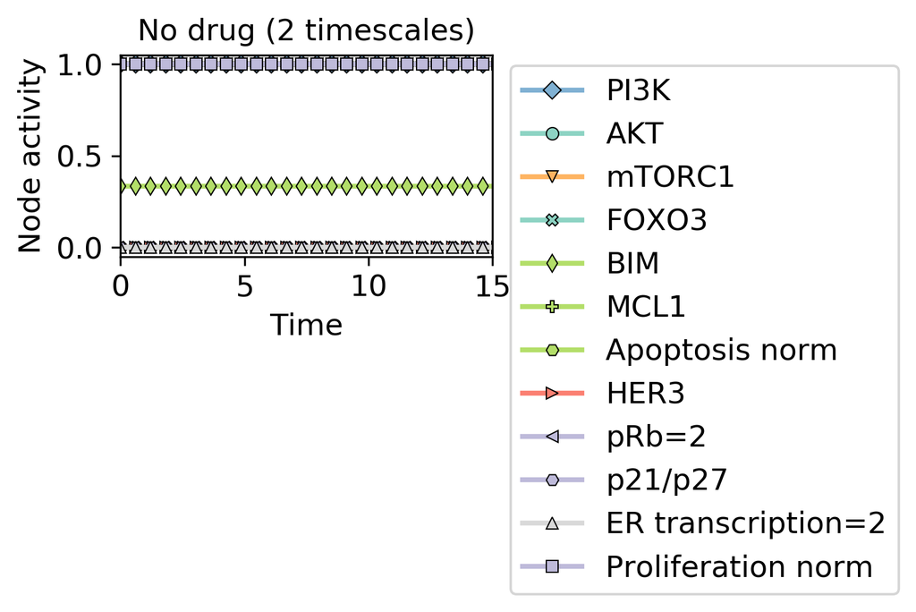

```python
filename='./Figures_ModifiedUpdateProbabilities/BreastCancerModel_ZanudoEtAl2020_MCF7'
df_plot=df_timecourse_alpelisib_0_M.iloc[::3, :]
ax = plt.gca()
df_plot.plot(kind='line',x='time',y='PI3K', marker='D',linestyle='-',c="#80b1d3",markeredgecolor = 'black',ax=ax)
df_plot.plot(kind='line',x='time',y='AKT', marker='o',linestyle='-',c="#8dd3c3",markeredgecolor = 'black',ax=ax)
df_plot.plot(kind='line',x='time',y='mTORC1',marker='v',linestyle='-',color="#feb462",markeredgecolor = 'black',ax=ax)
df_plot.plot(kind='line',x='time',y='FOXO3',marker='X',linestyle='-',c="#8dd3c3",markeredgecolor = 'black',ax=ax)
df_plot.plot(kind='line',x='time',y='BIM',marker='d',linestyle='-',c="#b3de69",markeredgecolor = 'black',ax=ax)
df_plot.plot(kind='line',x='time',y='MCL1',marker='P',linestyle='-',c="#b3de69",markeredgecolor = 'black',ax=ax)
df_plot.plot(kind='line',x='time',y='Apoptosis_norm',marker='H',linestyle='-',c="#b3de69",markeredgecolor = 'black',ax=ax)
df_plot.plot(kind='line',x='time',y='HER3',marker='>',linestyle='-',c="#fb8072ff",markeredgecolor = 'black',ax=ax)
df_plot.plot(kind='line',x='time',y='pRb_2',marker='<',linestyle='-',c="#bebada",markeredgecolor = 'black',ax=ax)
df_plot.plot(kind='line',x='time',y='p21_p27',marker='H',linestyle='-',c="#bebada",markeredgecolor = 'black',ax=ax)
df_plot.plot(kind='line',x='time',y='ER_transcription_2',marker='^',linestyle='-',color="#d9d9d9",markeredgecolor = 'black',ax=ax)
df_plot.plot(kind='line',x='time',y='Proliferation_norm',marker='s',linestyle='-',c="#bebada",markeredgecolor = 'black',ax=ax)
plt.legend(['PI3K','AKT','mTORC1',"FOXO3","BIM","MCL1",'Apoptosis norm',"HER3","pRb=2","p21/p27","ER transcription=2",'Proliferation norm'],bbox_to_anchor=(1.01, 1.02), loc=2, prop={'size':12})
plt.ylabel('Node activity')
plt.xlabel('Time')
plt.title("No drug (2 timescales)", fontsize=12)
plt.xlim([0,15])
plt.ylim([-0.05,1.05])
savefig(filename+'.svg', bbox_inches='tight',dpi=450)
savefig(filename+'.png', bbox_inches='tight',dpi=300)
plt.close()
Image(filename=filename+".png")
```

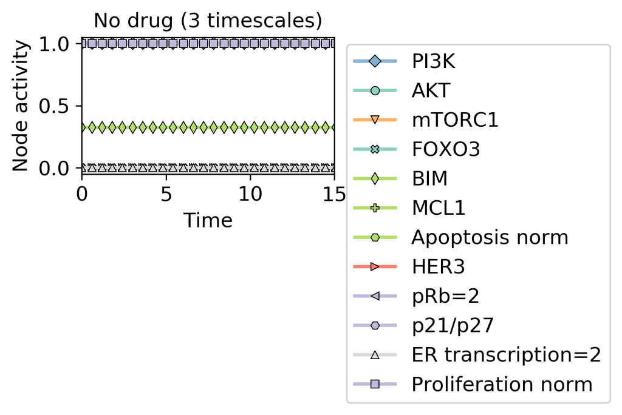

```python
filename='./Figures_ModifiedUpdateProbabilities/BreastCancerModel_ZanudoEtAl2020_MCF7_3timescales'
df_plot=df_timecourse_alpelisib_0_M_3timescales.iloc[::3, :]
ax = plt.gca()
df_plot.plot(kind='line',x='time',y='PI3K', marker='D',linestyle='-',c="#80b1d3",markeredgecolor = 'black',ax=ax)
df_plot.plot(kind='line',x='time',y='AKT', marker='o',linestyle='-',c="#8dd3c3",markeredgecolor = 'black',ax=ax)
df_plot.plot(kind='line',x='time',y='mTORC1',marker='v',linestyle='-',color="#feb462",markeredgecolor = 'black',ax=ax)
df_plot.plot(kind='line',x='time',y='FOXO3',marker='X',linestyle='-',c="#8dd3c3",markeredgecolor = 'black',ax=ax)
df_plot.plot(kind='line',x='time',y='BIM',marker='d',linestyle='-',c="#b3de69",markeredgecolor = 'black',ax=ax)
df_plot.plot(kind='line',x='time',y='MCL1',marker='P',linestyle='-',c="#b3de69",markeredgecolor = 'black',ax=ax)
df_plot.plot(kind='line',x='time',y='Apoptosis_norm',marker='H',linestyle='-',c="#b3de69",markeredgecolor = 'black',ax=ax)
df_plot.plot(kind='line',x='time',y='HER3',marker='>',linestyle='-',c="#fb8072ff",markeredgecolor = 'black',ax=ax)
df_plot.plot(kind='line',x='time',y='pRb_2',marker='<',linestyle='-',c="#bebada",markeredgecolor = 'black',ax=ax)
df_plot.plot(kind='line',x='time',y='p21_p27',marker='H',linestyle='-',c="#bebada",markeredgecolor = 'black',ax=ax)
df_plot.plot(kind='line',x='time',y='ER_transcription_2',marker='^',linestyle='-',color="#d9d9d9",markeredgecolor = 'black',ax=ax)
df_plot.plot(kind='line',x='time',y='Proliferation_norm',marker='s',linestyle='-',c="#bebada",markeredgecolor = 'black',ax=ax)
plt.legend(['PI3K','AKT','mTORC1',"FOXO3","BIM","MCL1",'Apoptosis norm',"HER3","pRb=2","p21/p27","ER transcription=2",'Proliferation norm'],bbox_to_anchor=(1.01, 1.02), loc=2, prop={'size':12})
plt.ylabel('Node activity')
plt.xlabel('Time')
plt.title("No drug (3 timescales)", fontsize=12)
plt.xlim([0,15])
plt.ylim([-0.05,1.05])
savefig(filename+'.svg', bbox_inches='tight',dpi=450)
savefig(filename+'.png', bbox_inches='tight',dpi=300)
plt.close()
Image(filename=filename+".png")
```

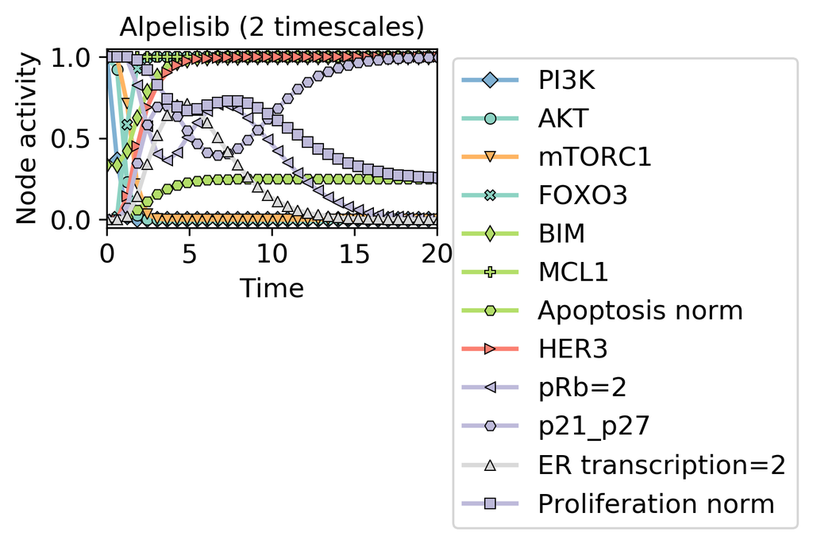

```python
filename='./Figures_ModifiedUpdateProbabilities/BreastCancerModel_ZanudoEtAl2020_MCF7_Alpelisib_1'
df_plot=df_timecourse_alpelisib_1_M.iloc[::3, :]
ax = plt.gca()
df_plot.plot(kind='line',x='time',y='PI3K', marker='D',linestyle='-',c="#80b1d3",markeredgecolor = 'black',ax=ax)
df_plot.plot(kind='line',x='time',y='AKT', marker='o',linestyle='-',c="#8dd3c3",markeredgecolor = 'black',ax=ax)
df_plot.plot(kind='line',x='time',y='mTORC1',marker='v',linestyle='-',color="#feb462",markeredgecolor = 'black',ax=ax)
df_plot.plot(kind='line',x='time',y='FOXO3',marker='X',linestyle='-',c="#8dd3c3",markeredgecolor = 'black',ax=ax)
df_plot.plot(kind='line',x='time',y='BIM',marker='d',linestyle='-',c="#b3de69",markeredgecolor = 'black',ax=ax)
df_plot.plot(kind='line',x='time',y='MCL1',marker='P',linestyle='-',c="#b3de69",markeredgecolor = 'black',ax=ax)
df_plot.plot(kind='line',x='time',y='Apoptosis_norm',marker='H',linestyle='-',c="#b3de69",markeredgecolor = 'black',ax=ax)
df_plot.plot(kind='line',x='time',y='HER3',marker='>',linestyle='-',c="#fb8072ff",markeredgecolor = 'black',ax=ax)
df_plot.plot(kind='line',x='time',y='pRb_2',marker='<',linestyle='-',c="#bebada",markeredgecolor = 'black',ax=ax)
df_plot.plot(kind='line',x='time',y='p21_p27',marker='H',linestyle='-',c="#bebada",markeredgecolor = 'black',ax=ax)
df_plot.plot(kind='line',x='time',y='ER_transcription_2',marker='^',linestyle='-',color="#d9d9d9",markeredgecolor = 'black',ax=ax)
df_plot.plot(kind='line',x='time',y='Proliferation_norm',marker='s',linestyle='-',c="#bebada",markeredgecolor = 'black',ax=ax)
plt.legend(['PI3K','AKT','mTORC1',"FOXO3","BIM","MCL1",'Apoptosis norm',"HER3","pRb=2","p21_p27","ER transcription=2",'Proliferation norm'],bbox_to_anchor=(1.01, 1.02), loc=2, prop={'size':12})
#ax.get_legend().remove()
plt.ylabel('Node activity')
plt.xlabel('Time')
plt.title("Alpelisib (2 timescales)", fontsize=12)
plt.xlim([0,20])
plt.ylim([-0.05,1.05])
savefig(filename+'.svg', bbox_inches='tight',dpi=450)
savefig(filename+'.png', bbox_inches='tight',dpi=300)
plt.close()
Image(filename=filename+".png")
```

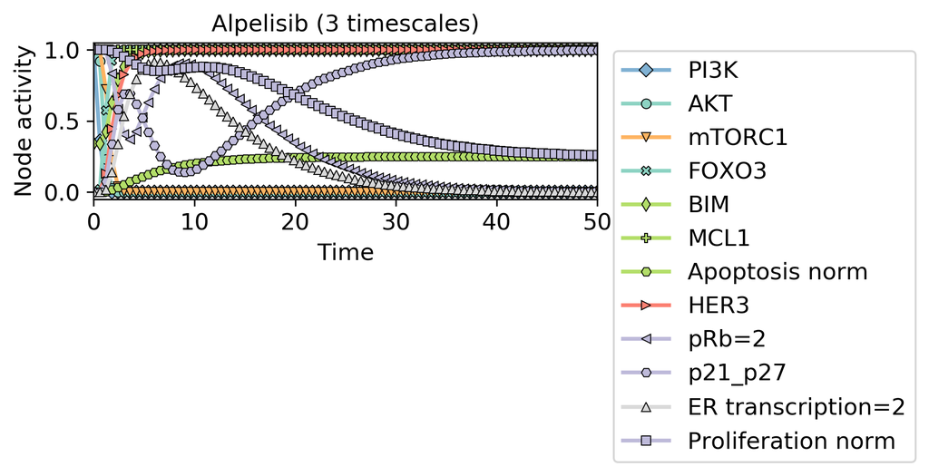

```python
pylab.rcParams['figure.figsize'] = (4.7, 1.5)
filename='./Figures_ModifiedUpdateProbabilities/BreastCancerModel_ZanudoEtAl2020_MCF7_Alpelisib_1_3timescales'
df_plot=df_timecourse_alpelisib_1_M_3timescales.iloc[::3, :]
ax = plt.gca()
df_plot.plot(kind='line',x='time',y='PI3K', marker='D',linestyle='-',c="#80b1d3",markeredgecolor = 'black',ax=ax)
df_plot.plot(kind='line',x='time',y='AKT', marker='o',linestyle='-',c="#8dd3c3",markeredgecolor = 'black',ax=ax)
df_plot.plot(kind='line',x='time',y='mTORC1',marker='v',linestyle='-',color="#feb462",markeredgecolor = 'black',ax=ax)
df_plot.plot(kind='line',x='time',y='FOXO3',marker='X',linestyle='-',c="#8dd3c3",markeredgecolor = 'black',ax=ax)
df_plot.plot(kind='line',x='time',y='BIM',marker='d',linestyle='-',c="#b3de69",markeredgecolor = 'black',ax=ax)
df_plot.plot(kind='line',x='time',y='MCL1',marker='P',linestyle='-',c="#b3de69",markeredgecolor = 'black',ax=ax)
df_plot.plot(kind='line',x='time',y='Apoptosis_norm',marker='H',linestyle='-',c="#b3de69",markeredgecolor = 'black',ax=ax)
df_plot.plot(kind='line',x='time',y='HER3',marker='>',linestyle='-',c="#fb8072ff",markeredgecolor = 'black',ax=ax)
df_plot.plot(kind='line',x='time',y='pRb_2',marker='<',linestyle='-',c="#bebada",markeredgecolor = 'black',ax=ax)
df_plot.plot(kind='line',x='time',y='p21_p27',marker='H',linestyle='-',c="#bebada",markeredgecolor = 'black',ax=ax)
df_plot.plot(kind='line',x='time',y='ER_transcription_2',marker='^',linestyle='-',color="#d9d9d9",markeredgecolor = 'black',ax=ax)
df_plot.plot(kind='line',x='time',y='Proliferation_norm',marker='s',linestyle='-',c="#bebada",markeredgecolor = 'black',ax=ax)
plt.legend(['PI3K','AKT','mTORC1',"FOXO3","BIM","MCL1",'Apoptosis norm',"HER3","pRb=2","p21_p27","ER transcription=2",'Proliferation norm'],bbox_to_anchor=(1.01, 1.02), loc=2, prop={'size':12})
#ax.get_legend().remove()
plt.ylabel('Node activity')
plt.xlabel('Time')
plt.title("Alpelisib (3 timescales)", fontsize=12)
plt.xlim([0,50])
plt.ylim([-0.05,1.05])
savefig(filename+'.svg', bbox_inches='tight',dpi=450)
savefig(filename+'.png', bbox_inches='tight',dpi=300)
plt.close()
Image(filename=filename+".png")
```

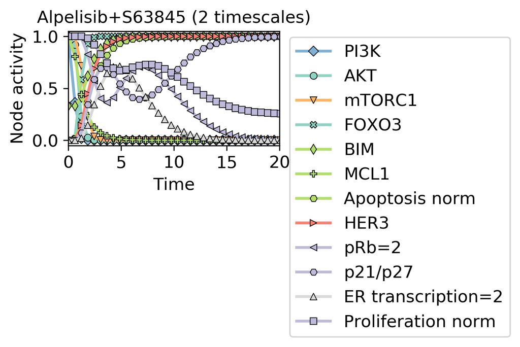

```python
pylab.rcParams['figure.figsize'] = (2.7, 1.5)
filename='./Figures_ModifiedUpdateProbabilities/BreastCancerModel_ZanudoEtAl2020_MCF7_Alpelisib_S63845_1'
df_plot=df_timecourse_alpelisib_1_S63845_1_M.iloc[::3, :]
ax = plt.gca()
df_plot.plot(kind='line',x='time',y='PI3K', marker='D',linestyle='-',c="#80b1d3",markeredgecolor = 'black',ax=ax)
df_plot.plot(kind='line',x='time',y='AKT', marker='o',linestyle='-',c="#8dd3c3",markeredgecolor = 'black',ax=ax)
df_plot.plot(kind='line',x='time',y='mTORC1',marker='v',linestyle='-',color="#feb462",markeredgecolor = 'black',ax=ax)
df_plot.plot(kind='line',x='time',y='FOXO3',marker='X',linestyle='-',c="#8dd3c3",markeredgecolor = 'black',ax=ax)
df_plot.plot(kind='line',x='time',y='BIM',marker='d',linestyle='-',c="#b3de69",markeredgecolor = 'black',ax=ax)
df_plot.plot(kind='line',x='time',y='MCL1',marker='P',linestyle='-',c="#b3de69",markeredgecolor = 'black',ax=ax)
df_plot.plot(kind='line',x='time',y='Apoptosis_norm',marker='H',linestyle='-',c="#b3de69",markeredgecolor = 'black',ax=ax)
df_plot.plot(kind='line',x='time',y='HER3',marker='>',linestyle='-',c="#fb8072ff",markeredgecolor = 'black',ax=ax)
df_plot.plot(kind='line',x='time',y='pRb_2',marker='<',linestyle='-',c="#bebada",markeredgecolor = 'black',ax=ax)
df_plot.plot(kind='line',x='time',y='p21_p27',marker='H',linestyle='-',c="#bebada",markeredgecolor = 'black',ax=ax)
df_plot.plot(kind='line',x='time',y='ER_transcription_2',marker='^',linestyle='-',color="#d9d9d9",markeredgecolor = 'black',ax=ax)
df_plot.plot(kind='line',x='time',y='Proliferation_norm',marker='s',linestyle='-',c="#bebada",markeredgecolor = 'black',ax=ax)
plt.legend(['PI3K','AKT','mTORC1',"FOXO3","BIM","MCL1",'Apoptosis norm',"HER3","pRb=2","p21/p27","ER transcription=2",'Proliferation norm'],bbox_to_anchor=(1.01, 1.02), loc=2, prop={'size':12})
#ax.get_legend().remove()
plt.ylabel('Node activity')
plt.xlabel('Time')
plt.title("Alpelisib+S63845 (2 timescales)", fontsize=12)
plt.xlim([0,20])
plt.ylim([-0.05,1.05])
savefig(filename+'.svg', bbox_inches='tight',dpi=450)
savefig(filename+'.png', bbox_inches='tight',dpi=300)
plt.close()
Image(filename=filename+".png")
```

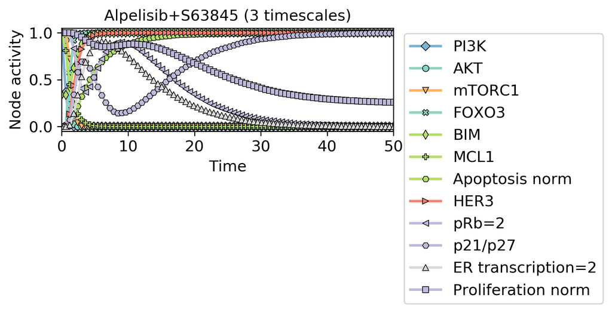

```python
pylab.rcParams['figure.figsize'] = (4.7, 1.5)
filename='./Figures_ModifiedUpdateProbabilities/BreastCancerModel_ZanudoEtAl2020_MCF7_Alpelisib_S63845_1'
df_plot=df_timecourse_alpelisib_1_S63845_1_M_3timescales.iloc[::3, :]
ax = plt.gca()
df_plot.plot(kind='line',x='time',y='PI3K', marker='D',linestyle='-',c="#80b1d3",markeredgecolor = 'black',ax=ax)
df_plot.plot(kind='line',x='time',y='AKT', marker='o',linestyle='-',c="#8dd3c3",markeredgecolor = 'black',ax=ax)
df_plot.plot(kind='line',x='time',y='mTORC1',marker='v',linestyle='-',color="#feb462",markeredgecolor = 'black',ax=ax)
df_plot.plot(kind='line',x='time',y='FOXO3',marker='X',linestyle='-',c="#8dd3c3",markeredgecolor = 'black',ax=ax)
df_plot.plot(kind='line',x='time',y='BIM',marker='d',linestyle='-',c="#b3de69",markeredgecolor = 'black',ax=ax)
df_plot.plot(kind='line',x='time',y='MCL1',marker='P',linestyle='-',c="#b3de69",markeredgecolor = 'black',ax=ax)
df_plot.plot(kind='line',x='time',y='Apoptosis_norm',marker='H',linestyle='-',c="#b3de69",markeredgecolor = 'black',ax=ax)
df_plot.plot(kind='line',x='time',y='HER3',marker='>',linestyle='-',c="#fb8072ff",markeredgecolor = 'black',ax=ax)
df_plot.plot(kind='line',x='time',y='pRb_2',marker='<',linestyle='-',c="#bebada",markeredgecolor = 'black',ax=ax)
df_plot.plot(kind='line',x='time',y='p21_p27',marker='H',linestyle='-',c="#bebada",markeredgecolor = 'black',ax=ax)
df_plot.plot(kind='line',x='time',y='ER_transcription_2',marker='^',linestyle='-',color="#d9d9d9",markeredgecolor = 'black',ax=ax)
df_plot.plot(kind='line',x='time',y='Proliferation_norm',marker='s',linestyle='-',c="#bebada",markeredgecolor = 'black',ax=ax)
plt.legend(['PI3K','AKT','mTORC1',"FOXO3","BIM","MCL1",'Apoptosis norm',"HER3","pRb=2","p21/p27","ER transcription=2",'Proliferation norm'],bbox_to_anchor=(1.01, 1.02), loc=2, prop={'size':12})
#ax.get_legend().remove()
plt.ylabel('Node activity')
plt.xlabel('Time')
plt.title("Alpelisib+S63845 (3 timescales)", fontsize=12)
plt.xlim([0,50])
plt.ylim([-0.05,1.05])
savefig(filename+'.svg', bbox_inches='tight',dpi=450)
savefig(filename+'.png', bbox_inches='tight',dpi=300)
plt.close()
Image(filename=filename+".png")
```

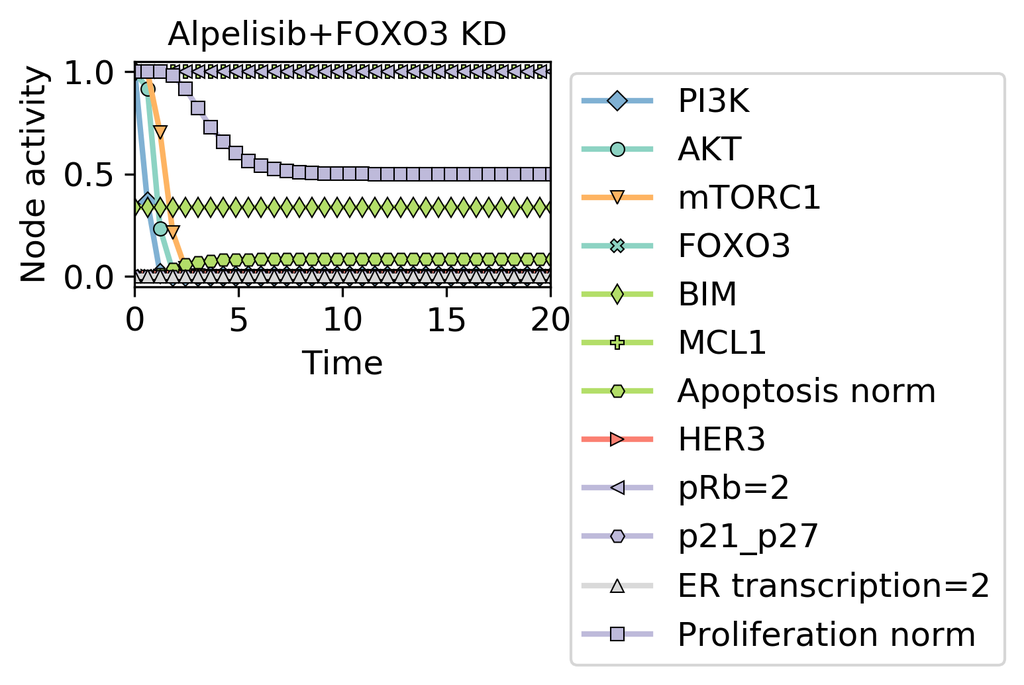

```python
pylab.rcParams['figure.figsize'] = (2.7, 1.5)
filename='./Figures_ModifiedUpdateProbabilities/BreastCancerModel_ZanudoEtAl2020_MCF7_Alpelisib_FOXO3_0'
df_plot=df_timecourse_alpelisib_1_foxo3_0_M.iloc[::3, :]
ax = plt.gca()
df_plot.plot(kind='line',x='time',y='PI3K', marker='D',linestyle='-',c="#80b1d3",markeredgecolor = 'black',ax=ax)
df_plot.plot(kind='line',x='time',y='AKT', marker='o',linestyle='-',c="#8dd3c3",markeredgecolor = 'black',ax=ax)
df_plot.plot(kind='line',x='time',y='mTORC1',marker='v',linestyle='-',color="#feb462",markeredgecolor = 'black',ax=ax)
df_plot.plot(kind='line',x='time',y='FOXO3',marker='X',linestyle='-',c="#8dd3c3",markeredgecolor = 'black',ax=ax)
df_plot.plot(kind='line',x='time',y='BIM',marker='d',linestyle='-',c="#b3de69",markeredgecolor = 'black',ax=ax)
df_plot.plot(kind='line',x='time',y='MCL1',marker='P',linestyle='-',c="#b3de69",markeredgecolor = 'black',ax=ax)
df_plot.plot(kind='line',x='time',y='Apoptosis_norm',marker='H',linestyle='-',c="#b3de69",markeredgecolor = 'black',ax=ax)
df_plot.plot(kind='line',x='time',y='HER3',marker='>',linestyle='-',c="#fb8072ff",markeredgecolor = 'black',ax=ax)
df_plot.plot(kind='line',x='time',y='pRb_2',marker='<',linestyle='-',c="#bebada",markeredgecolor = 'black',ax=ax)
df_plot.plot(kind='line',x='time',y='p21_p27',marker='H',linestyle='-',c="#bebada",markeredgecolor = 'black',ax=ax)
df_plot.plot(kind='line',x='time',y='ER_transcription_2',marker='^',linestyle='-',color="#d9d9d9",markeredgecolor = 'black',ax=ax)
df_plot.plot(kind='line',x='time',y='Proliferation_norm',marker='s',linestyle='-',c="#bebada",markeredgecolor = 'black',ax=ax)
plt.legend(['PI3K','AKT','mTORC1',"FOXO3","BIM","MCL1",'Apoptosis norm',"HER3","pRb=2","p21_p27","ER transcription=2",'Proliferation norm'],bbox_to_anchor=(1.01, 1.02), loc=2, prop={'size':12})
#ax.get_legend().remove()
plt.ylabel('Node activity')
plt.xlabel('Time')
plt.title("Alpelisib+FOXO3 KD ", fontsize=12)
plt.xlim([0,20])
plt.ylim([-0.05,1.05])
savefig(filename+'.svg', bbox_inches='tight',dpi=450)
savefig(filename+'.png', bbox_inches='tight',dpi=300)
plt.close()
Image(filename=filename+".png")
```

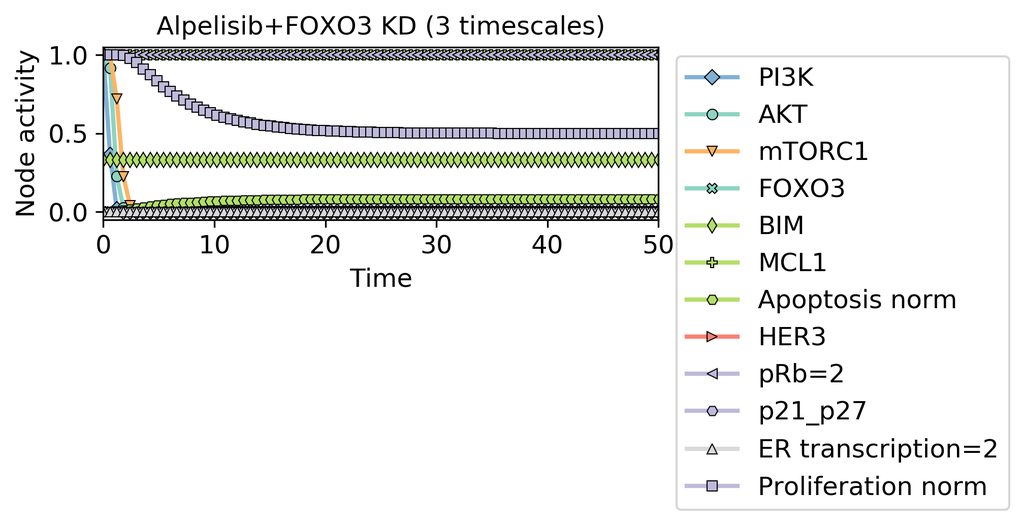

```python
pylab.rcParams['figure.figsize'] = (4.7, 1.5)
filename='./Figures_ModifiedUpdateProbabilities/BreastCancerModel_ZanudoEtAl2020_MCF7_Alpelisib_FOXO3_0'
df_plot=df_timecourse_alpelisib_1_foxo3_0_M_3timescales.iloc[::3, :]
ax = plt.gca()
df_plot.plot(kind='line',x='time',y='PI3K', marker='D',linestyle='-',c="#80b1d3",markeredgecolor = 'black',ax=ax)
df_plot.plot(kind='line',x='time',y='AKT', marker='o',linestyle='-',c="#8dd3c3",markeredgecolor = 'black',ax=ax)
df_plot.plot(kind='line',x='time',y='mTORC1',marker='v',linestyle='-',color="#feb462",markeredgecolor = 'black',ax=ax)
df_plot.plot(kind='line',x='time',y='FOXO3',marker='X',linestyle='-',c="#8dd3c3",markeredgecolor = 'black',ax=ax)
df_plot.plot(kind='line',x='time',y='BIM',marker='d',linestyle='-',c="#b3de69",markeredgecolor = 'black',ax=ax)
df_plot.plot(kind='line',x='time',y='MCL1',marker='P',linestyle='-',c="#b3de69",markeredgecolor = 'black',ax=ax)
df_plot.plot(kind='line',x='time',y='Apoptosis_norm',marker='H',linestyle='-',c="#b3de69",markeredgecolor = 'black',ax=ax)
df_plot.plot(kind='line',x='time',y='HER3',marker='>',linestyle='-',c="#fb8072ff",markeredgecolor = 'black',ax=ax)
df_plot.plot(kind='line',x='time',y='pRb_2',marker='<',linestyle='-',c="#bebada",markeredgecolor = 'black',ax=ax)
df_plot.plot(kind='line',x='time',y='p21_p27',marker='H',linestyle='-',c="#bebada",markeredgecolor = 'black',ax=ax)
df_plot.plot(kind='line',x='time',y='ER_transcription_2',marker='^',linestyle='-',color="#d9d9d9",markeredgecolor = 'black',ax=ax)
df_plot.plot(kind='line',x='time',y='Proliferation_norm',marker='s',linestyle='-',c="#bebada",markeredgecolor = 'black',ax=ax)
plt.legend(['PI3K','AKT','mTORC1',"FOXO3","BIM","MCL1",'Apoptosis norm',"HER3","pRb=2","p21_p27","ER transcription=2",'Proliferation norm'],bbox_to_anchor=(1.01, 1.02), loc=2, prop={'size':12})
#ax.get_legend().remove()
plt.ylabel('Node activity')
plt.xlabel('Time')
plt.title("Alpelisib+FOXO3 KD (3 timescales)", fontsize=12)
plt.xlim([0,50])
plt.ylim([-0.05,1.05])
savefig(filename+'.svg', bbox_inches='tight',dpi=450)
savefig(filename+'.png', bbox_inches='tight',dpi=300)
plt.close()
Image(filename=filename+".png")
```

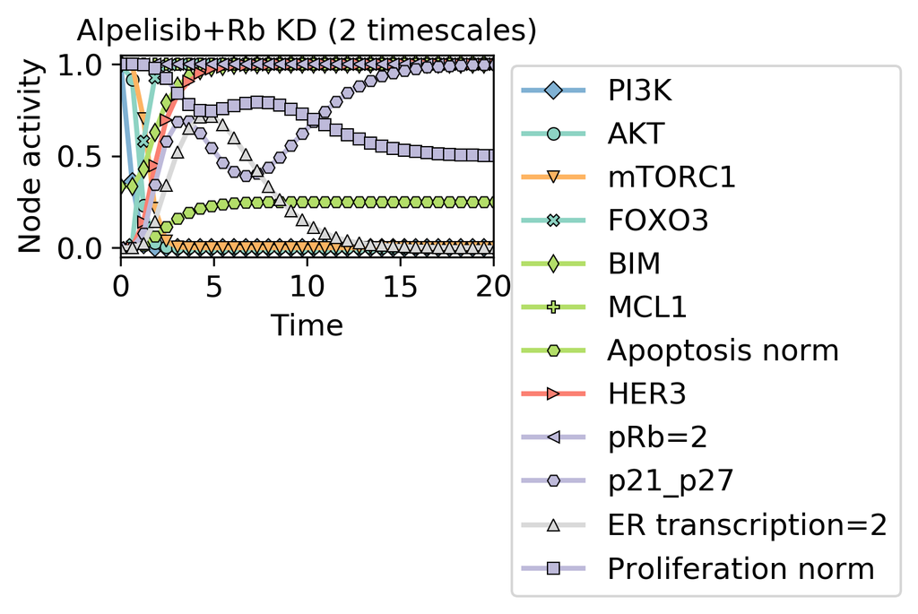

```python
pylab.rcParams['figure.figsize'] = (2.7, 1.5)
filename='./Figures_ModifiedUpdateProbabilities/BreastCancerModel_ZanudoEtAl2020_MCF7_Alpelisib_RbT_0'
df_plot=df_timecourse_alpelisib_1_RbT_0_M.iloc[::3, :]
ax = plt.gca()
df_plot.plot(kind='line',x='time',y='PI3K', marker='D',linestyle='-',c="#80b1d3",markeredgecolor = 'black',ax=ax)
df_plot.plot(kind='line',x='time',y='AKT', marker='o',linestyle='-',c="#8dd3c3",markeredgecolor = 'black',ax=ax)
df_plot.plot(kind='line',x='time',y='mTORC1',marker='v',linestyle='-',color="#feb462",markeredgecolor = 'black',ax=ax)
df_plot.plot(kind='line',x='time',y='FOXO3',marker='X',linestyle='-',c="#8dd3c3",markeredgecolor = 'black',ax=ax)
df_plot.plot(kind='line',x='time',y='BIM',marker='d',linestyle='-',c="#b3de69",markeredgecolor = 'black',ax=ax)
df_plot.plot(kind='line',x='time',y='MCL1',marker='P',linestyle='-',c="#b3de69",markeredgecolor = 'black',ax=ax)
df_plot.plot(kind='line',x='time',y='Apoptosis_norm',marker='H',linestyle='-',c="#b3de69",markeredgecolor = 'black',ax=ax)
df_plot.plot(kind='line',x='time',y='HER3',marker='>',linestyle='-',c="#fb8072ff",markeredgecolor = 'black',ax=ax)
df_plot.plot(kind='line',x='time',y='pRb_2',marker='<',linestyle='-',c="#bebada",markeredgecolor = 'black',ax=ax)
df_plot.plot(kind='line',x='time',y='p21_p27',marker='H',linestyle='-',c="#bebada",markeredgecolor = 'black',ax=ax)
df_plot.plot(kind='line',x='time',y='ER_transcription_2',marker='^',linestyle='-',color="#d9d9d9",markeredgecolor = 'black',ax=ax)
df_plot.plot(kind='line',x='time',y='Proliferation_norm',marker='s',linestyle='-',c="#bebada",markeredgecolor = 'black',ax=ax)
plt.legend(['PI3K','AKT','mTORC1',"FOXO3","BIM","MCL1",'Apoptosis norm',"HER3","pRb=2","p21_p27","ER transcription=2",'Proliferation norm'],bbox_to_anchor=(1.01, 1.02), loc=2, prop={'size':12})
#ax.get_legend().remove()
plt.ylabel('Node activity')
plt.xlabel('Time')
plt.title("Alpelisib+Rb KD (2 timescales)", fontsize=12)
plt.xlim([0,20])
plt.ylim([-0.05,1.05])
savefig(filename+'.svg', bbox_inches='tight',dpi=450)
savefig(filename+'.png', bbox_inches='tight',dpi=300)
plt.close()
Image(filename=filename+".png")
```

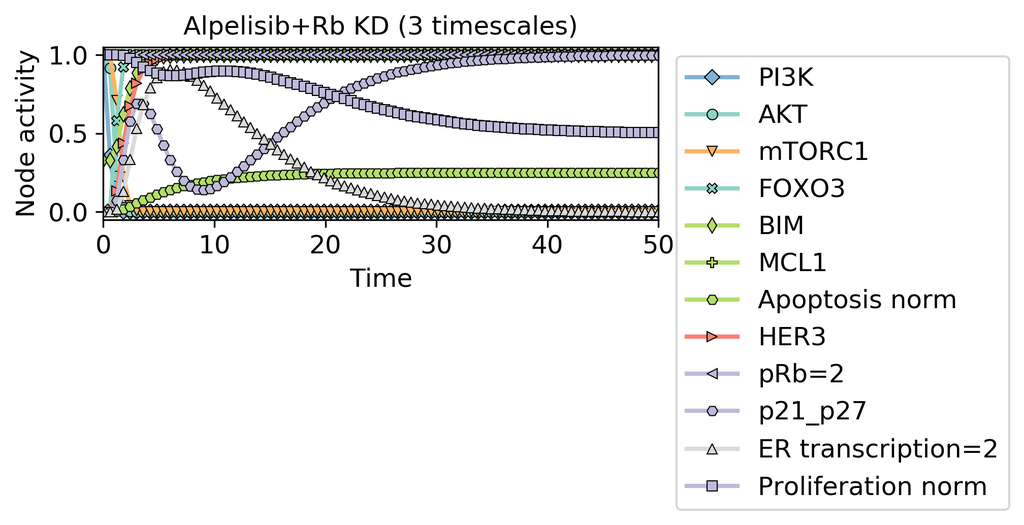

```python
pylab.rcParams['figure.figsize'] = (4.7, 1.5)
filename='./Figures_ModifiedUpdateProbabilities/BreastCancerModel_ZanudoEtAl2020_MCF7_Alpelisib_RbT_0'
df_plot=df_timecourse_alpelisib_1_RbT_0_M_3timescales.iloc[::3, :]
ax = plt.gca()
df_plot.plot(kind='line',x='time',y='PI3K', marker='D',linestyle='-',c="#80b1d3",markeredgecolor = 'black',ax=ax)
df_plot.plot(kind='line',x='time',y='AKT', marker='o',linestyle='-',c="#8dd3c3",markeredgecolor = 'black',ax=ax)
df_plot.plot(kind='line',x='time',y='mTORC1',marker='v',linestyle='-',color="#feb462",markeredgecolor = 'black',ax=ax)
df_plot.plot(kind='line',x='time',y='FOXO3',marker='X',linestyle='-',c="#8dd3c3",markeredgecolor = 'black',ax=ax)
df_plot.plot(kind='line',x='time',y='BIM',marker='d',linestyle='-',c="#b3de69",markeredgecolor = 'black',ax=ax)
df_plot.plot(kind='line',x='time',y='MCL1',marker='P',linestyle='-',c="#b3de69",markeredgecolor = 'black',ax=ax)
df_plot.plot(kind='line',x='time',y='Apoptosis_norm',marker='H',linestyle='-',c="#b3de69",markeredgecolor = 'black',ax=ax)
df_plot.plot(kind='line',x='time',y='HER3',marker='>',linestyle='-',c="#fb8072ff",markeredgecolor = 'black',ax=ax)
df_plot.plot(kind='line',x='time',y='pRb_2',marker='<',linestyle='-',c="#bebada",markeredgecolor = 'black',ax=ax)
df_plot.plot(kind='line',x='time',y='p21_p27',marker='H',linestyle='-',c="#bebada",markeredgecolor = 'black',ax=ax)
df_plot.plot(kind='line',x='time',y='ER_transcription_2',marker='^',linestyle='-',color="#d9d9d9",markeredgecolor = 'black',ax=ax)
df_plot.plot(kind='line',x='time',y='Proliferation_norm',marker='s',linestyle='-',c="#bebada",markeredgecolor = 'black',ax=ax)
plt.legend(['PI3K','AKT','mTORC1',"FOXO3","BIM","MCL1",'Apoptosis norm',"HER3","pRb=2","p21_p27","ER transcription=2",'Proliferation norm'],bbox_to_anchor=(1.01, 1.02), loc=2, prop={'size':12})
#ax.get_legend().remove()
plt.ylabel('Node activity')
plt.xlabel('Time')
plt.title("Alpelisib+Rb KD (3 timescales)", fontsize=12)
plt.xlim([0,50])
plt.ylim([-0.05,1.05])
savefig(filename+'.svg', bbox_inches='tight',dpi=450)
savefig(filename+'.png', bbox_inches='tight',dpi=300)
plt.close()
Image(filename=filename+".png")
```

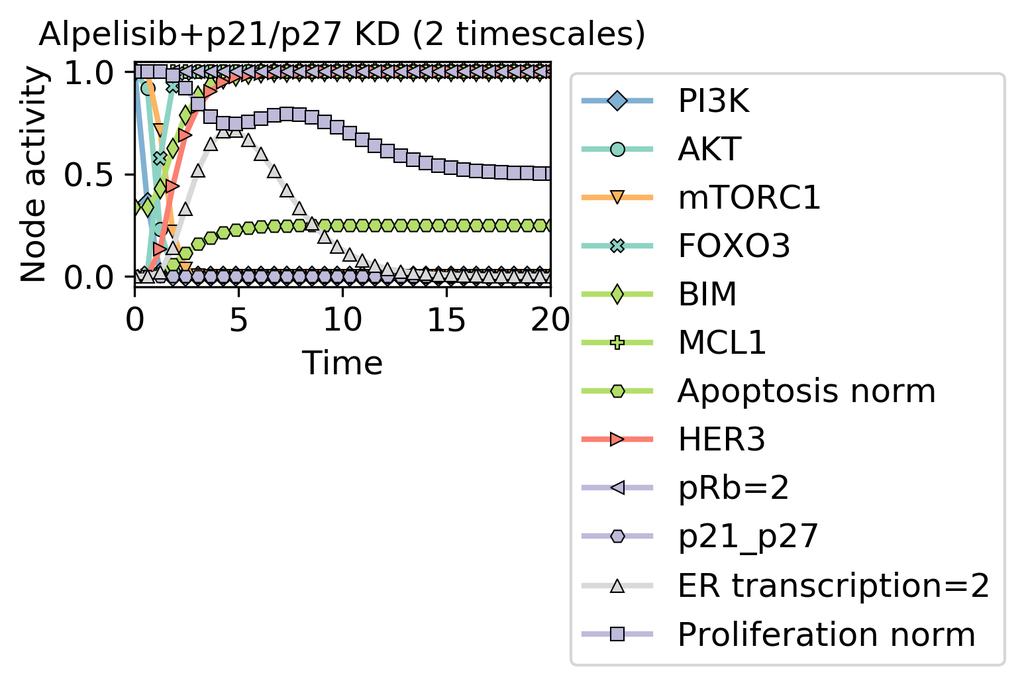

```python
pylab.rcParams['figure.figsize'] = (2.7, 1.5)
filename='./Figures_ModifiedUpdateProbabilities/BreastCancerModel_ZanudoEtAl2020_MCF7_Alpelisib_p21p27T_0'
df_plot=df_timecourse_alpelisib_1_P21P27T_0_M.iloc[::3, :]
ax = plt.gca()
df_plot.plot(kind='line',x='time',y='PI3K', marker='D',linestyle='-',c="#80b1d3",markeredgecolor = 'black',ax=ax)
df_plot.plot(kind='line',x='time',y='AKT', marker='o',linestyle='-',c="#8dd3c3",markeredgecolor = 'black',ax=ax)
df_plot.plot(kind='line',x='time',y='mTORC1',marker='v',linestyle='-',color="#feb462",markeredgecolor = 'black',ax=ax)
df_plot.plot(kind='line',x='time',y='FOXO3',marker='X',linestyle='-',c="#8dd3c3",markeredgecolor = 'black',ax=ax)
df_plot.plot(kind='line',x='time',y='BIM',marker='d',linestyle='-',c="#b3de69",markeredgecolor = 'black',ax=ax)
df_plot.plot(kind='line',x='time',y='MCL1',marker='P',linestyle='-',c="#b3de69",markeredgecolor = 'black',ax=ax)
df_plot.plot(kind='line',x='time',y='Apoptosis_norm',marker='H',linestyle='-',c="#b3de69",markeredgecolor = 'black',ax=ax)
df_plot.plot(kind='line',x='time',y='HER3',marker='>',linestyle='-',c="#fb8072ff",markeredgecolor = 'black',ax=ax)
df_plot.plot(kind='line',x='time',y='pRb_2',marker='<',linestyle='-',c="#bebada",markeredgecolor = 'black',ax=ax)
df_plot.plot(kind='line',x='time',y='p21_p27',marker='H',linestyle='-',c="#bebada",markeredgecolor = 'black',ax=ax)
df_plot.plot(kind='line',x='time',y='ER_transcription_2',marker='^',linestyle='-',color="#d9d9d9",markeredgecolor = 'black',ax=ax)
df_plot.plot(kind='line',x='time',y='Proliferation_norm',marker='s',linestyle='-',c="#bebada",markeredgecolor = 'black',ax=ax)
plt.legend(['PI3K','AKT','mTORC1',"FOXO3","BIM","MCL1",'Apoptosis norm',"HER3","pRb=2","p21_p27","ER transcription=2",'Proliferation norm'],bbox_to_anchor=(1.01, 1.02), loc=2, prop={'size':12})
#ax.get_legend().remove()
plt.ylabel('Node activity')
plt.xlabel('Time')
plt.title("Alpelisib+p21/p27 KD (2 timescales)", fontsize=12)
plt.xlim([0,20])
plt.ylim([-0.05,1.05])
savefig(filename+'.svg', bbox_inches='tight',dpi=450)
savefig(filename+'.png', bbox_inches='tight',dpi=300)
plt.close()
Image(filename=filename+".png")
```

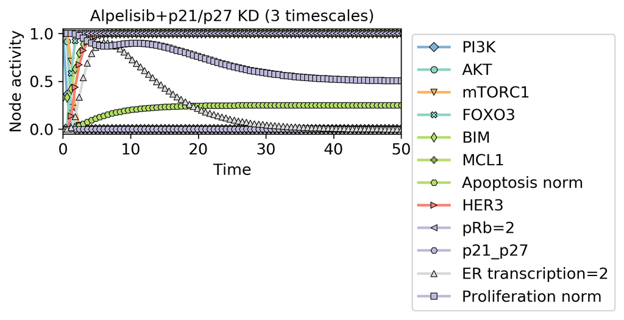

```python
pylab.rcParams['figure.figsize'] = (4.7, 1.5)
filename='./Figures_ModifiedUpdateProbabilities/BreastCancerModel_ZanudoEtAl2020_MCF7_Alpelisib_p21p27T_0'
df_plot=df_timecourse_alpelisib_1_P21P27T_0_M_3timescales.iloc[::3, :]
ax = plt.gca()
df_plot.plot(kind='line',x='time',y='PI3K', marker='D',linestyle='-',c="#80b1d3",markeredgecolor = 'black',ax=ax)
df_plot.plot(kind='line',x='time',y='AKT', marker='o',linestyle='-',c="#8dd3c3",markeredgecolor = 'black',ax=ax)
df_plot.plot(kind='line',x='time',y='mTORC1',marker='v',linestyle='-',color="#feb462",markeredgecolor = 'black',ax=ax)
df_plot.plot(kind='line',x='time',y='FOXO3',marker='X',linestyle='-',c="#8dd3c3",markeredgecolor = 'black',ax=ax)
df_plot.plot(kind='line',x='time',y='BIM',marker='d',linestyle='-',c="#b3de69",markeredgecolor = 'black',ax=ax)
df_plot.plot(kind='line',x='time',y='MCL1',marker='P',linestyle='-',c="#b3de69",markeredgecolor = 'black',ax=ax)
df_plot.plot(kind='line',x='time',y='Apoptosis_norm',marker='H',linestyle='-',c="#b3de69",markeredgecolor = 'black',ax=ax)
df_plot.plot(kind='line',x='time',y='HER3',marker='>',linestyle='-',c="#fb8072ff",markeredgecolor = 'black',ax=ax)
df_plot.plot(kind='line',x='time',y='pRb_2',marker='<',linestyle='-',c="#bebada",markeredgecolor = 'black',ax=ax)
df_plot.plot(kind='line',x='time',y='p21_p27',marker='H',linestyle='-',c="#bebada",markeredgecolor = 'black',ax=ax)
df_plot.plot(kind='line',x='time',y='ER_transcription_2',marker='^',linestyle='-',color="#d9d9d9",markeredgecolor = 'black',ax=ax)
df_plot.plot(kind='line',x='time',y='Proliferation_norm',marker='s',linestyle='-',c="#bebada",markeredgecolor = 'black',ax=ax)
plt.legend(['PI3K','AKT','mTORC1',"FOXO3","BIM","MCL1",'Apoptosis norm',"HER3","pRb=2","p21_p27","ER transcription=2",'Proliferation norm'],bbox_to_anchor=(1.01, 1.02), loc=2, prop={'size':12})
#ax.get_legend().remove()
plt.ylabel('Node activity')
plt.xlabel('Time')
plt.title("Alpelisib+p21/p27 KD (3 timescales)", fontsize=12)
plt.xlim([0,50])
plt.ylim([-0.05,1.05])
savefig(filename+'.svg', bbox_inches='tight',dpi=450)
savefig(filename+'.png', bbox_inches='tight',dpi=300)
plt.close()
Image(filename=filename+".png")
```

The $Apoptosis_{norm}$ and $Proliferation_{norm}$ for each perturbation and cell-specific-model will be put in the df_model_results dataframe. We output this dataframe as the *BreastCancerModel_ZanudoEtAl2020_3timescales.csv* file.

```python
Proliferation_norm=[]
Apoptosis_norm=[]
Perturbation=[]
Cell_line=[]
Timescale=[]

df_timecourse=df_timecourse_alpelisib_0_M
Proliferation_norm.append(df_timecourse.iloc[-1,]["Proliferation_norm"])
Apoptosis_norm.append(df_timecourse.iloc[-1,]["Apoptosis_norm"])
Perturbation.append("None")
Cell_line.append("MCF7")
Timescale.append("2 timescales")

df_timecourse=df_timecourse_alpelisib_1_M
Proliferation_norm.append(df_timecourse.iloc[-1,]["Proliferation_norm"])
Apoptosis_norm.append(df_timecourse.iloc[-1,]["Apoptosis_norm"])
Perturbation.append("Alpelisib")
Cell_line.append("MCF7")
Timescale.append("2 timescales")

df_timecourse=df_timecourse_alpelisib_1_foxo3_0_M
Proliferation_norm.append(df_timecourse.iloc[-1,]["Proliferation_norm"])
Apoptosis_norm.append(df_timecourse.iloc[-1,]["Apoptosis_norm"])
Perturbation.append("Alpelisib+FOXO3=0")
Cell_line.append("MCF7")
Timescale.append("2 timescales")

df_timecourse=df_timecourse_alpelisib_1_RbT_0_M
Proliferation_norm.append(df_timecourse.iloc[-1,]["Proliferation_norm"])
Apoptosis_norm.append(df_timecourse.iloc[-1,]["Apoptosis_norm"])
Perturbation.append("Alpelisib+Rb_T=0")
Cell_line.append("MCF7")
Timescale.append("2 timescales")

df_timecourse=df_timecourse_alpelisib_1_S63845_1_M
Proliferation_norm.append(df_timecourse.iloc[-1,]["Proliferation_norm"])
Apoptosis_norm.append(df_timecourse.iloc[-1,]["Apoptosis_norm"])
Perturbation.append("Alpelisib+S63845")
Cell_line.append("MCF7")
Timescale.append("2 timescales")

df_timecourse=df_timecourse_alpelisib_1_P21P27T_0_M
Proliferation_norm.append(df_timecourse.iloc[-1,]["Proliferation_norm"])
Apoptosis_norm.append(df_timecourse.iloc[-1,]["Apoptosis_norm"])
Perturbation.append("Alpelisib+p21/p27_T=0")
Cell_line.append("MCF7")
Timescale.append("2 timescales")

df_timecourse=df_timecourse_alpelisib_0_M_3timescales
Proliferation_norm.append(df_timecourse.iloc[-1,]["Proliferation_norm"])
Apoptosis_norm.append(df_timecourse.iloc[-1,]["Apoptosis_norm"])
Perturbation.append("None")
Cell_line.append("MCF7")
Timescale.append("3 timescales")

df_timecourse=df_timecourse_alpelisib_1_M_3timescales
Proliferation_norm.append(df_timecourse.iloc[-1,]["Proliferation_norm"])
Apoptosis_norm.append(df_timecourse.iloc[-1,]["Apoptosis_norm"])
Perturbation.append("Alpelisib")
Cell_line.append("MCF7")
Timescale.append("3 timescales")

df_timecourse=df_timecourse_alpelisib_1_foxo3_0_M_3timescales
Proliferation_norm.append(df_timecourse.iloc[-1,]["Proliferation_norm"])
Apoptosis_norm.append(df_timecourse.iloc[-1,]["Apoptosis_norm"])
Perturbation.append("Alpelisib+FOXO3=0")
Cell_line.append("MCF7")
Timescale.append("3 timescales")

df_timecourse=df_timecourse_alpelisib_1_RbT_0_M_3timescales
Proliferation_norm.append(df_timecourse.iloc[-1,]["Proliferation_norm"])
Apoptosis_norm.append(df_timecourse.iloc[-1,]["Apoptosis_norm"])
Perturbation.append("Alpelisib+Rb_T=0")
Cell_line.append("MCF7")
Timescale.append("3 timescales")

df_timecourse=df_timecourse_alpelisib_1_S63845_1_M_3timescales
Proliferation_norm.append(df_timecourse.iloc[-1,]["Proliferation_norm"])
Apoptosis_norm.append(df_timecourse.iloc[-1,]["Apoptosis_norm"])
Perturbation.append("Alpelisib+S63845")
Cell_line.append("MCF7")
Timescale.append("3 timescales")

df_timecourse=df_timecourse_alpelisib_1_P21P27T_0_M_3timescales
Proliferation_norm.append(df_timecourse.iloc[-1,]["Proliferation_norm"])
Apoptosis_norm.append(df_timecourse.iloc[-1,]["Apoptosis_norm"])
Perturbation.append("Alpelisib+p21/p27_T=0")
Cell_line.append("MCF7")
Timescale.append("3 timescales")
```

```python
df_model_results=pd.DataFrame(list(zip(Proliferation_norm, Apoptosis_norm,Perturbation,Cell_line,Timescale)), columns =["Proliferation_norm", "Apoptosis_norm","Perturbation","Cell_line","Timescale"])
df_model_results=df_model_results.sort_values(by=['Perturbation']).reset_index(drop=True)
df_model_results.to_csv("BreastCancerModel_ZanudoEtAl2020_3timescales.csv",index=False)
```

```python
pd.set_option('display.max_rows', 100)
df_model_results
```

|  | Proliferation_norm | Apoptosis_norm | Perturbation | Cell_line | Timescale |
| --- | --- | --- | --- | --- | --- |
| 0 | 0.250350 | 0.250000 | Alpelisib | MCF7 | 2 timescales |
| 1 | 0.250025 | 0.250000 | Alpelisib | MCF7 | 3 timescales |
| 2 | 0.500000 | 0.084075 | Alpelisib+FOXO3=0 | MCF7 | 2 timescales |
| 3 | 0.500000 | 0.082725 | Alpelisib+FOXO3=0 | MCF7 | 3 timescales |
| 4 | 0.500050 | 0.250000 | Alpelisib+Rb_T=0 | MCF7 | 2 timescales |
| 5 | 0.500000 | 0.250000 | Alpelisib+Rb_T=0 | MCF7 | 3 timescales |
| 6 | 0.250375 | 1.000000 | Alpelisib+S63845 | MCF7 | 2 timescales |
| 7 | 0.250025 | 1.000000 | Alpelisib+S63845 | MCF7 | 3 timescales |
| 8 | 0.500050 | 0.250000 | Alpelisib+p21/p27_T=0 | MCF7 | 2 timescales |
| 9 | 0.500000 | 0.250000 | Alpelisib+p21/p27_T=0 | MCF7 | 3 timescales |
| 10 | 1.000000 | 0.000000 | None | MCF7 | 2 timescales |
| 11 | 1.000000 | 0.000000 | None | MCF7 | 3 timescales |